# Assignment 3

DATA311 - Machine Learning

Author

Rin Meng, 51940633

# **Exploratory Data Analysis**

## Exercise 1

```r
sal <- read.csv('datasalaries.csv', header = TRUE)

sal <- na.omit(sal)

sal$company <- as.factor(sal$company)
sal$gender <- as.factor(sal$gender)
sal$Race <- as.factor(sal$Race)
sal$Education <- as.factor(sal$Education)

str(sal)
```

```
'data.frame':   7517 obs. of  7 variables:
 $ company          : Factor w/ 6 levels "Amazon","Apple",..: 4 5 4 5 1 1 2 1 1 3 ...
 $ salary           : int  400000 136000 337000 222000 310000 620000 180000 210000 142000 242000 ...
 $ yearsofexperience: int  5 3 6 4 15 19 1 4 0 2 ...
 $ yearsatcompany   : int  5 2 6 4 3 7 1 1 0 2 ...
 $ gender           : Factor w/ 3 levels "Female","Male",..: 2 2 2 2 2 2 2 2 2 2 ...
 $ Race             : Factor w/ 5 levels "Asian","Black",..: 1 4 1 1 1 1 1 3 1 5 ...
 $ Education        : Factor w/ 5 levels "Bachelor's Degree",..: 4 1 1 3 1 1 1 2 3 3 ...
```

## Exercise 2

```r
set.seed(51940633)

sample_size <- floor(0.5 * nrow(sal))
set <- sample(seq_len(nrow(sal)), size = sample_size)

sal_train <- sal[set, ]
sal_test <- sal[-set, ]

nrow(sal_train)
```

```
[1] 3758
```

```r
nrow(sal_test)
```

```
[1] 3759
```

# **Decision Trees**

## Exercise 3

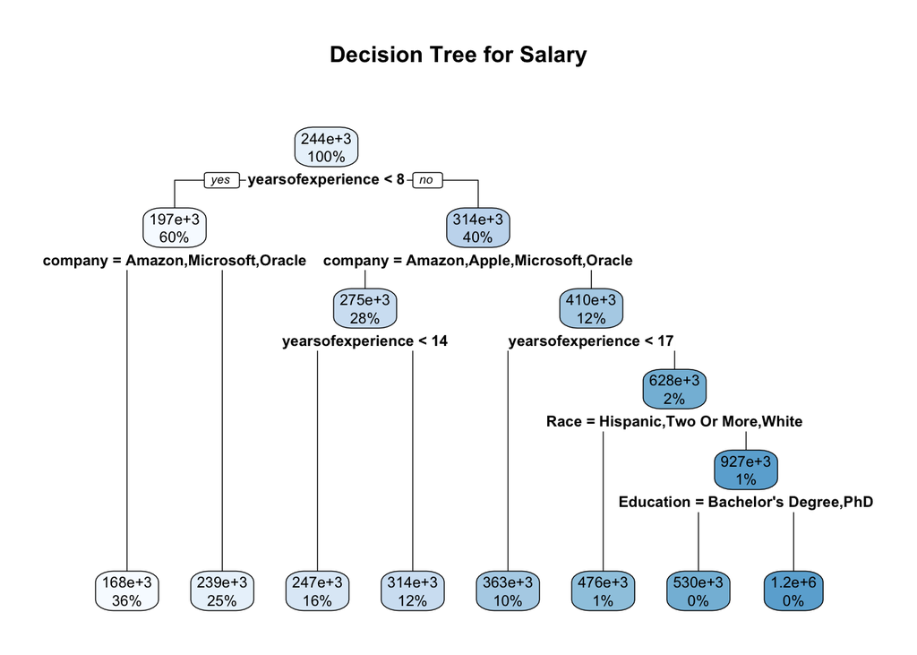

```r
library(rpart)
library(rpart.plot)

tree_model <- rpart(salary ~ ., data = sal_train, method = "anova")

rpart.plot(tree_model, main = "Decision Tree for Salary")
```

Root Node

- People had an average salary of $244k.
- Represents 100% of the people (before splitting)
1. First Split (Years of Experience < 8)
- If they had years of experience < 8 (left branch)
  - Average salary $197k
  - 60% of the people had less than 8 years of experience
- If the had years of experience > 8 (right branch)
  - Average salary $314k
  - 40% of the people had more than 8 years of experience
2. Second Split (Salary based on company)
- People with less than 8 years of experience, and their company is: Amazon, Microsoft, Oracle (left branch)
  - The 36% of them with Amazon, Microsoft, Oracle had average salary of $168k
  - The 25% of them with Google, Facebook, and Apple, had average salary of $239k
- People with more than 8 years of experience, and their company is: Amazon, Apple, Microsoft, Oracle (right branch)
  - The 28% of them with Amazon, Apple, Microsoft, Oracle had an average salary of $275k
  - The 12% of them with Google, Facebook had an average salary of $410k.
3. Third Split (Applicable only to people with more than 8 years of experience)
- People with Amazon, Apple, Microsoft, Oracle
  - People that had less than 14 years of experience,
    - Had an average salary of $247k
    - 16% of the people matches this criteria
  - People that had more than 14 years of experience
    - Had an average salary of $314k
    - 12% of the people matches this criteria
- People with Google, Facebook
  - People that had less than 17 years of experience
    - Had an average salary of $363k
    - 10% of the people matches this criteria
  - People that had more than 17 years of experience
    - Had an average salary of $628k
    - 2% of the people matches this criteria

## Exercise 4

```r
tree_prediciton <- predict(tree_model, newdata=sal_test)


residuals <- tree_prediciton - sal_test$salary

rmse <- sqrt(mean(residuals^2))
print(rmse)
```

```
[1] 126144.5
```

This means that on average, our prediction is off from the actual prediction by ~ $126k.

# **Random Forest**

## Exercise 5

```r
library(randomForest)
set.seed(51940633)

rF_model <- randomForest(salary ~ ., data= sal_train, ntree = 500, importance = TRUE)

print(rF_model)
```

```
Call:
 randomForest(formula = salary ~ ., data = sal_train, ntree = 500,      importance = TRUE)
               Type of random forest: regression
                     Number of trees: 500
No. of variables tried at each split: 2

          Mean of squared residuals: 20809050168
                    % Var explained: 28.17
```

```r
importance(rF_model)
```

```
                    %IncMSE IncNodePurity
company           21.880168  1.693508e+13
yearsofexperience 21.057544  2.747138e+13
yearsatcompany     9.412203  1.798385e+13
gender             2.943639  1.432117e+12
Race               7.492215  6.237038e+12
Education          1.931411  4.481656e+12
```

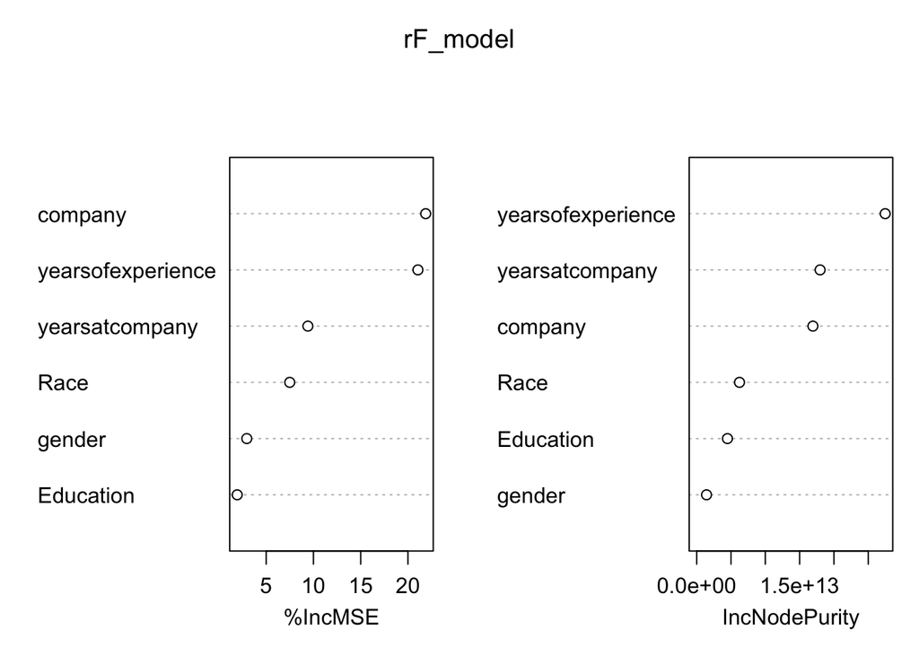

```r
varImpPlot(rF_model)
```

The random forest model is explaining only 28.17% of variance in the salary data, and the mean squared residual is a bit high, suggesting the model might not be a great fit or needs further refinement.

With the importance function and the importance plot, we can clearly see that the predictors that contributes the most is the company (21.88%), yearsofexperience (21.06%) and yearsatcompany (9.41%), because % Increase of MSE (%IncMSE) indicates the impact of the predictor on the model’s performance, and when the value of that predictor is randomly shuffled, the MSE increases by the percentage given (importance function).

Therefore, a high %IncMSE = model is getting worse because it’s losing its important predictors, which implies that predictors company and yearsofexperience has more significant impact, compared to other variables like Race, gender, and Education.

## Exercise 6

```r
rF_prediction <- predict(rF_model, newdata = sal_test)

rF_rmse <- sqrt(mean((sal_test$salary - rF_prediction)^2))


rF_mse <- mean(rF_model$mse)
rF_oob_rmse <- sqrt(rF_mse)

print(paste("Test RMSE:", rF_rmse))
```

```
[1] "Test RMSE: 113525.911942828"
```

```r
print(paste("OOB RMSE:", rF_oob_rmse))
```

```
[1] "OOB RMSE: 144930.752629496"
```

## Exercise 7

```r
var_importance <- importance(rF_model)

print(var_importance)
```

```
                    %IncMSE IncNodePurity
company           21.880168  1.693508e+13
yearsofexperience 21.057544  2.747138e+13
yearsatcompany     9.412203  1.798385e+13
gender             2.943639  1.432117e+12
Race               7.492215  6.237038e+12
Education          1.931411  4.481656e+12
```

## Exercise 8

```r
set.seed(51940633*2)
rF_bagging <- randomForest(salary ~ ., data = sal_train,
                           ntree = 500, mtry = ncol(sal_train) - 1, importance = TRUE)

print(rF_bagging)
```

```
Call:
 randomForest(formula = salary ~ ., data = sal_train, ntree = 500,      mtry = ncol(sal_train) - 1, importance = TRUE)
               Type of random forest: regression
                     Number of trees: 500
No. of variables tried at each split: 6

          Mean of squared residuals: 22922329881
                    % Var explained: 20.87
```

## Exercise 9

```r
rF_bagging_predictions <- predict(rF_bagging, newdata = sal_test)
test_rmse <- sqrt(mean((sal_test$salary - rF_bagging_predictions)^2))

oob_mse <- mean(rF_bagging$mse)
oob_rmse <- sqrt(oob_mse)

print(paste("Test RMSE:", test_rmse))
```

```
[1] "Test RMSE: 136067.943619341"
```

```r
print(paste("OOB RMSE:", oob_rmse))
```

```
[1] "OOB RMSE: 152175.31486125"
```

## Exercise 10

```r
importance(rF_bagging)
```

```
                    %IncMSE IncNodePurity
company           26.536530  1.527305e+13
yearsofexperience 19.485428  3.528312e+13
yearsatcompany    11.513530  1.966637e+13
gender             4.990314  1.755819e+12
Race               8.793760  1.095388e+13
Education          7.387364  6.508204e+12
```

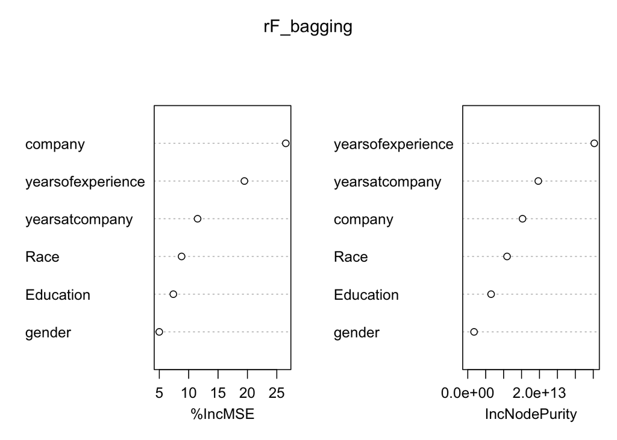

```r
varImpPlot(rF_bagging)
```

# **Regularization**

## Exercise 11

```r
train_predictors_matrix <- model.matrix(salary ~ ., data = sal_train)[, -1]
test_predictors_matrix <- model.matrix(salary ~ ., data = sal_test)[, -1]
head(test_predictors_matrix)
```

```
  companyApple companyFacebook companyGoogle companyMicrosoft companyOracle
1            0               0             1                0             0
2            0               0             0                1             0
5            0               0             0                0             0
7            1               0             0                0             0
8            0               0             0                0             0
9            0               0             0                0             0
  yearsofexperience yearsatcompany genderMale genderOther RaceBlack
1                 5              5          1           0         0
2                 3              2          1           0         0
5                15              3          1           0         0
7                 1              1          1           0         0
8                 4              1          1           0         0
9                 0              0          1           0         0
  RaceHispanic RaceTwo Or More RaceWhite EducationHighschool
1            0               0         0                   0
2            0               1         0                   0
5            0               0         0                   0
7            0               0         0                   0
8            1               0         0                   1
9            0               0         0                   0
  EducationMaster's Degree EducationPhD EducationSome College
1                        0            1                     0
2                        0            0                     0
5                        0            0                     0
7                        0            0                     0
8                        0            0                     0
9                        1            0                     0
```

```r
head(train_predictors_matrix)
```

```
     companyApple companyFacebook companyGoogle companyMicrosoft companyOracle
3826            0               0             0                1             0
3894            0               1             0                0             0
1027            0               0             0                0             1
6065            0               0             0                0             0
562             0               0             0                0             0
800             0               0             0                1             0
     yearsofexperience yearsatcompany genderMale genderOther RaceBlack
3826                25             14          1           0         0
3894                20              2          1           0         0
1027                35             23          1           0         0
6065                 1              0          1           0         0
562                 11              8          1           0         0
800                 13              2          1           0         0
     RaceHispanic RaceTwo Or More RaceWhite EducationHighschool
3826            0               0         0                   0
3894            1               0         0                   0
1027            0               0         1                   0
6065            0               0         1                   0
562             0               0         0                   0
800             0               0         0                   0
     EducationMaster's Degree EducationPhD EducationSome College
3826                        1            0                     0
3894                        1            0                     0
1027                        0            0                     0
6065                        0            0                     0
562                         1            0                     0
800                         1            0                     0
```

## Exercise 12

```r
library(glmnet)
y <- sal_train$salary
ridge_model <- glmnet(train_predictors_matrix, y, alpha = 0)

print(ridge_model)
```

```
Call:  glmnet(x = train_predictors_matrix, y = y, alpha = 0)

    Df  %Dev   Lambda
1   17  0.00 67860000
2   17  0.18 61830000
3   17  0.20 56340000
4   17  0.22 51330000
5   17  0.24 46770000
6   17  0.26 42620000
7   17  0.29 38830000
8   17  0.31 35380000
9   17  0.34 32240000
10  17  0.38 29370000
11  17  0.41 26760000
12  17  0.45 24390000
```

[output cut: 88 more lines]

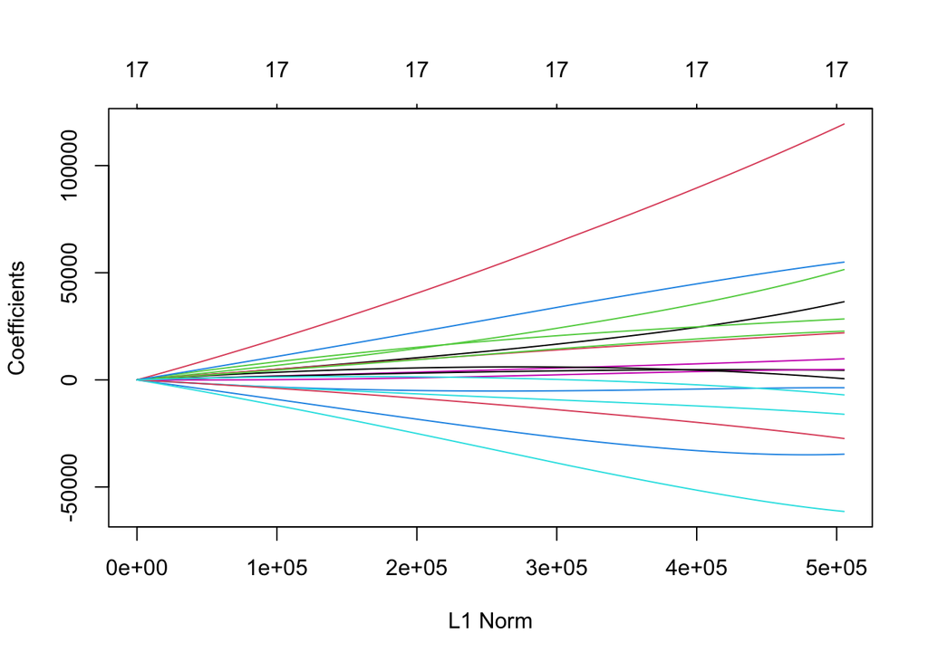

```r
plot(ridge_model)
```

## Exercise 13

```r
library(glmnet)

set.seed(51940633)

# Perform cross-validation on the Ridge regression model
cv_model <- cv.glmnet(x = train_predictors_matrix, y = y, alpha = 0)

# Print out the best lambda values
best_lambda <- cv_model$lambda.min
one_se_lambda <- cv_model$lambda.1se

cat("Best lambda (minimizing CV error):", best_lambda, "\n")
```

```
Best lambda (minimizing CV error): 6785.613
```

```r
cat("Lambda within 1 standard error:", one_se_lambda, "\n")
```

```
Lambda within 1 standard error: 6040655
```

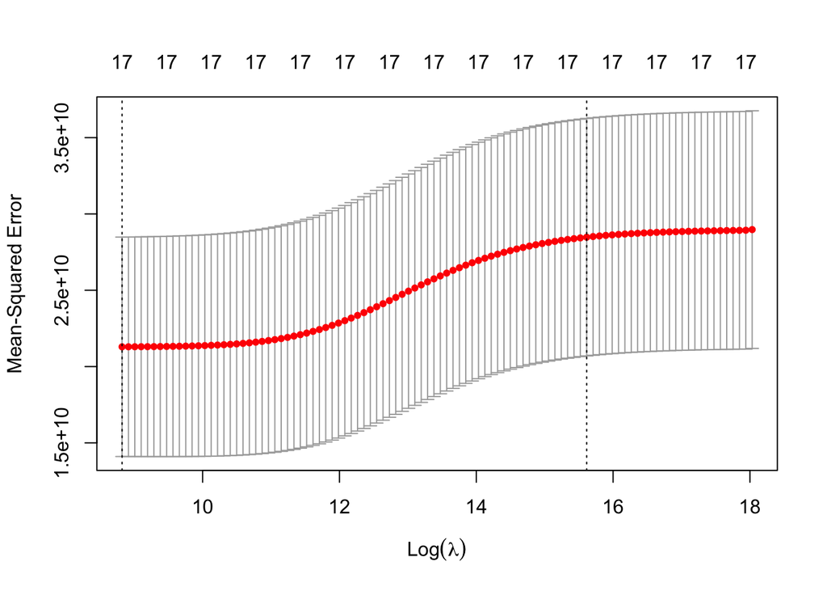

```r
plot(cv_model)
```

## Exercise 14

```r
ridge_best_model <- glmnet(train_predictors_matrix, y, alpha = 0, lambda = best_lambda)

ridge_predictions <- predict(ridge_best_model, newx = test_predictors_matrix)

test_residuals <- ridge_predictions - sal_test$salary
test_rmse <- sqrt(mean(test_residuals^2))
print(paste("Test RMSE for Ridge regression:", test_rmse))
```

```
[1] "Test RMSE for Ridge regression: 105667.423661998"
```

With the Test RMSE, on average, the Ridge regression model’s predictions for salary are off by $105,667.42 from the actual values in the test set.

## Exercise 15

```r
ridge_1se_model <- glmnet(train_predictors_matrix, y, alpha = 0, lambda = one_se_lambda)

# Make predictions on the test set
ridge_1se_predictions <- predict(ridge_1se_model, newx = test_predictors_matrix)

# Calculate the test RMSE
test_residuals_1se <- ridge_1se_predictions - sal_test$salary
test_rmse_1se <- sqrt(mean(test_residuals_1se^2))

# Print the test RMSE for lambda.1se
print(paste("Test RMSE for Ridge regression with lambda.1se:", test_rmse_1se))
```

```
[1] "Test RMSE for Ridge regression with lambda.1se: 133603.209757378"
```

Now, on average, the model’s predictions for the test set are off by approximately $133,603.21 from the actual salary values. This is another bias-variance trade off, because we are applying regularization, we lose some accuracy, making our model more prone to variance, therefore, a higher test RMSE with the Ridge regression with `lambda.1se`.

## Exercise 16

```r
# Fit the LASSO model with glmnet (alpha = 1 for LASSO)
lasso_model <- glmnet(train_predictors_matrix, y, alpha = 1)

# Print the LASSO model coefficients
print(lasso_model)
```

```
Call:  glmnet(x = train_predictors_matrix, y = y, alpha = 1)

   Df  %Dev Lambda
1   0  0.00  67860
2   1  2.70  61830
3   1  4.94  56340
4   1  6.80  51330
5   1  8.34  46770
6   1  9.63  42620
7   2 10.92  38830
8   2 12.72  35380
9   2 14.21  32240
10  2 15.45  29370
11  2 16.48  26760
12  2 17.34  24390
```

[output cut: 55 more lines]

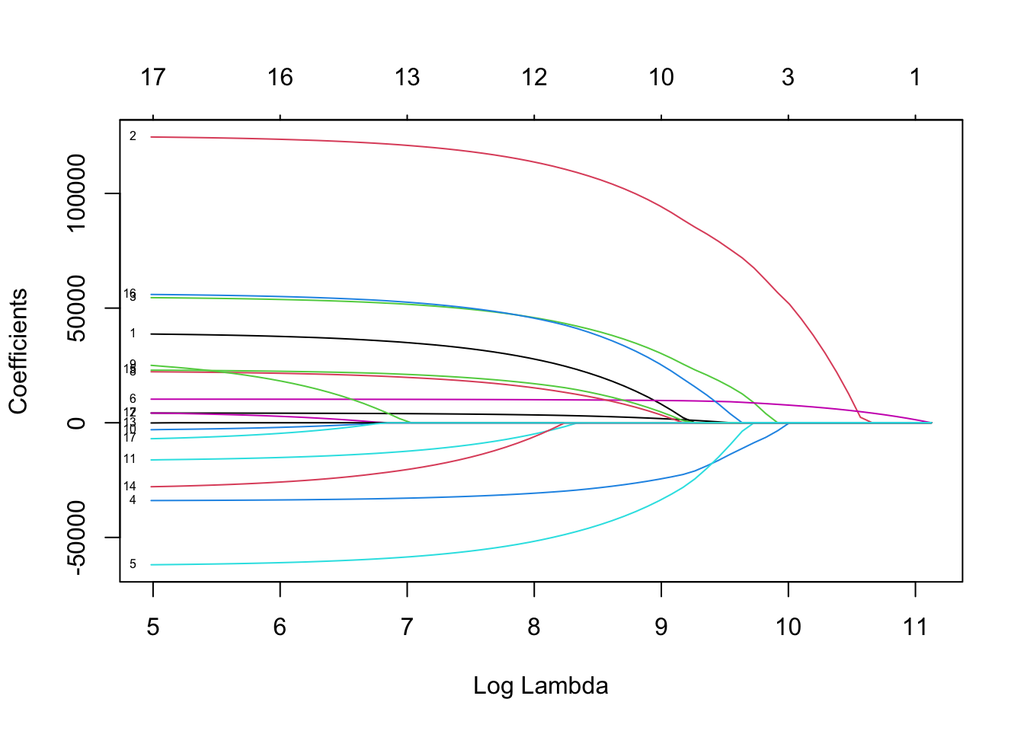

```r
# Plot the LASSO model path
plot(lasso_model, xvar = "lambda", label = TRUE)
```

## Exercise 17

```r
# Load necessary library
library(glmnet)

# Set the seed for reproducibility
set.seed(123)

# Fit the LASSO model using cross-validation
lasso_cv <- cv.glmnet(x = train_predictors_matrix, y = y, alpha = 1)

# View the best lambda (lambda that minimizes cross-validation error)
best_lambda <- lasso_cv$lambda.min
cat("Best lambda from cross-validation:", best_lambda, "\n")
```

```
Best lambda from cross-validation: 1242.268
```

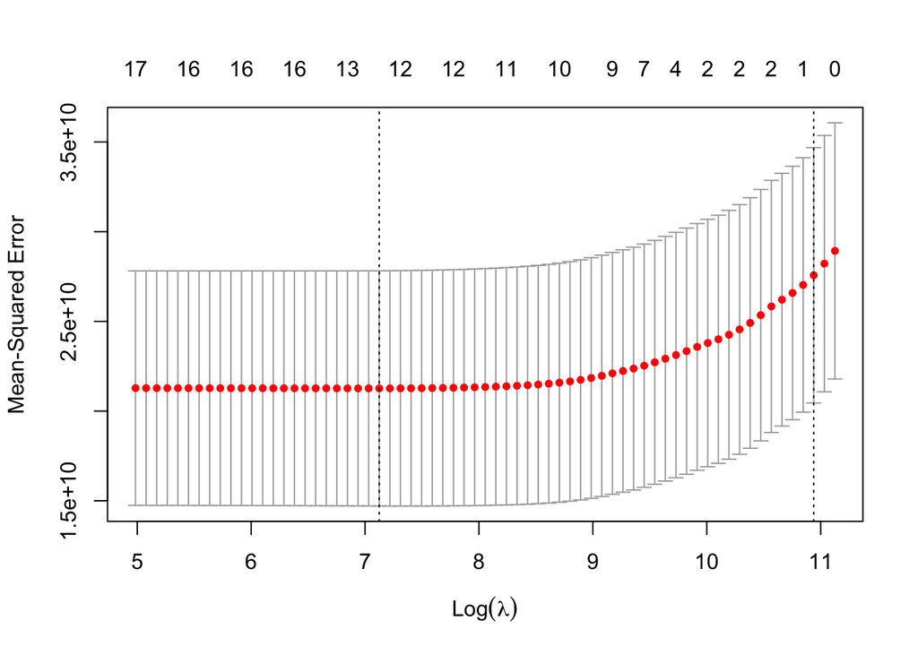

```r
# Plot the cross-validation error curve
plot(lasso_cv)
```

```r
# You can also check the lambda value within one standard error of the minimum
best_lambda_1se <- lasso_cv$lambda.1se
cat("Lambda within 1 SE of minimum:", best_lambda_1se, "\n")
```

```
Lambda within 1 SE of minimum: 56335.35
```

## Exercise 18

```r
# Calculate the predictions for the test set using the best lambda
lasso_best_model <- glmnet(x = train_predictors_matrix, y = y, alpha = 1, lambda = lasso_cv$lambda.min)

# Make predictions on the test data
test_predictions <- predict(lasso_best_model, s = best_lambda, newx = test_predictors_matrix)

test_y <- sal_test$salary
# Calculate the RMSE on the test set
test_rmse <- sqrt(mean((test_predictions - test_y)^2))

# Print the test RMSE
cat("Test RMSE for LASSO model with best lambda:", test_rmse, "\n")
```

```
Test RMSE for LASSO model with best lambda: 106000.3
```

## Exercise 19

```r
# Use the lambda.1se value from the cross-validation output
best_lambda_1se <- lasso_cv$lambda.1se
cat("Best lambda within 1 SE of minimum:", best_lambda_1se, "\n")
```

```
Best lambda within 1 SE of minimum: 56335.35
```

```r
# Fit the LASSO model using the best lambda within 1 SE of minimum
lasso_best_model_1se <- glmnet(x = train_predictors_matrix, y = y, alpha = 1, lambda = best_lambda_1se)

# Make predictions on the test set
test_predictions_1se <- predict(lasso_best_model_1se, s = best_lambda_1se, newx = test_predictors_matrix)

# Calculate the RMSE on the test set using the predictions
test_rmse_1se <- sqrt(mean((test_predictions_1se - test_y)^2))

# Print the test RMSE for the best lambda within 1 SE
cat("Test RMSE for LASSO model with lambda within 1 SE of minimum:", test_rmse_1se, "\n")
```

```
Test RMSE for LASSO model with lambda within 1 SE of minimum: 130294
```

## Exercise 20

[output not shown]

Overall, we can clearly see that the best model that performed on our test data set was the ridge model, on average, predictions of salary made by the ridge model is off by about ~$105k.